# R implementation for causal moderated mediation analysis

This document illustrates the implementation of the R package `moderate.mediation`. The package is for researchers to estimate and test the conditional and moderated mediation effects, assess their sensitivity to unmeasured pretreatment confounding, and visualize the results. We built the package based on the Monte Carlo method (default) and the bootstrapping method. When the sample size is small (e.g., n = 50 or 100 under the studied conditions in the simulations), and the mediator or the outcome is binary, we recommend the bootstrapping method, because it generates point estimates with smaller bias than the Monte Carlo method. Otherwise, we recommend the Monte Carlo method, because its running speed is much faster and its statistical power is slightly higher at a small sample size when both the mediator and outcome are continuous. Because a relatively large sample size is usually required to detect a significant moderated mediation effect, we set the Monte Carlo method to be the default method. The package is applicable to a binary or continuous treatment, a binary or continuous mediator, a binary or continuous outcome, and one or more moderators of any scale.

**Loading the package**:

```r
library(moderate.mediation)
```

We will use data from the National Evaluation of Welfare-to-Work Strategies (NEWWS) study. The study randomly assigned 694 participants, who were mostly low-income single mothers with young children. Labor Force Attachment (LFA) program (208) aimed at moving low-income parents from welfare to work by providing employment-focused incentives and services. Control group (486) received aid from the Aid to Families with Dependent Children (AFDC) program without requirement for working.

**Import the data**:

```r
data(newws)
```

**Research Question**: How is the LFA impact on maternal depression transmitted through employment?

**Treatment**:

`treat` 1 if a participant was assigned to LFA and 0 otherwise.

**Outcome**:

`depression` maternal depression at the end of the second year after randomization, which is a summary score of 12 items measuring depressive symptoms during the past week on a 0-3 scale.

**Mediator**: `emp` 1 if one was ever employed during the two-year period after randomization.

**Pretreatment Covariates**:

`nevmar` 1 if never married and 0 otherwise.

`emp_prior` 1 if employed at baseline and 0 otherwise.

`hispanic` 1 if Hispanic and 0 otherwise.

`ADCPC` welfare amount in the year before randomization

`attitude` a composite score of two attitude items - so many family problems that I cannot work at a full time or part time job; so much to do during the day that I cannot go to a school or job training program - measured on the scale of 1-4.

`depress_prior` a composite score of three depressive symptom items - sad, depressed, blues, and lonely - in the week before randomization measured on the scale of 1-4.

`workpref` one’s level of preference for taking care of family full time than working on the scale of 1-4.

`nohsdip` 1 if had never obtained a high school diploma or a General Educational Development certificate and 0 otherwise.

### 1. Estimation and inference

The estimation and inference are conducted via the `modmed` function. A challenge of moderated mediation analysis lies in the specification of the mediator and outcome models, which can be very complex as more interactions are involved. To ease model building, the function allows users to specify the main model predictors and the moderators of each main model coefficient following the hierarchical form. In the NEWWS example, with a binary treatment, a binary mediator, and a continuous outcome, we assume that paths T➔M, T➔Y, M➔Y, and TM➔Y are moderated by the number of children and welfare amount at baseline, while X➔M and X➔Y are not moderated. We are interested in the difference in the mediation mechanism between those who had three or more children and those who had two children at baseline, while baseline welfare amount is set at its median, 5050. Hence, we specified the function as follows:

```r
data(newws)
results = modmed(data = newws,
                 treatment = "treat",
                 mediator = "emp",
                 outcome = "depression",
                 covariates.disc = c("emp_prior", "nevmar", "hispanic", "nohsdip"),
                 covariates.cont = c("workpref", "attitude", "depress_prior"),
                 moderators.disc = "CHCNT",
                 moderators.cont = "ADCPC",
                 m.model = list(intercept = c("ADCPC", "CHCNT"), treatment =
                 c("ADCPC", "CHCNT"), emp_prior = NULL,
                 nevmar = NULL, hispanic = NULL, nohsdip = NULL, workpref = NULL,
                 attitude = NULL, depress_prior = NULL),
                 y.model = list(intercept = c("ADCPC", "CHCNT"), treatment =
                 c("ADCPC", "CHCNT"), mediator = c("ADCPC", "CHCNT"), tm =
                 c("ADCPC", "CHCNT"), emp_prior = NULL, nevmar = NULL, hispanic =
                 NULL, nohsdip = NULL, workpref = NULL, attitude = NULL,
                 depress_prior = NULL),
                 comp.treatment.value = 1,
                 ref.treatment.value = 0,
                 comp.mod.disc.values = 3,
                 ref.mod.disc.values = 2,
                 comp.mod.cont.values = 5050,
                 ref.mod.cont.values = 5050,
                 m.scale = "binary",
                 y.scale = "continuous",
                 method = "mc",
                 nmc = 1000,
                 conf.level = 0.95,
                 seed = 1)
```

**Variable names** Users are required to specify the names of the data, treatment, mediator, and outcome via the arguments, `data`, `treatment`, `mediator`, and `outcome`. If there are any missing values in the data, users need to impute them before running the function. Whenever applicable, names of the discrete and continuous moderators $\bf{W}$ and other pretreatment covariates $\bf{X}$ are specified separately via `moderators.disc`, `moderators.cont`, `covariates.disc`, and `covariates.cont`, whose default values are `NULL`. For example, if there are no discrete moderators, users do not need to specify `moderators.disc`. Users do not need to reformat discrete variables. No matter if the discrete variables are coded as string or numerical values, the program can automatically factorize them. This eases data cleaning and avoids mistakes.

$\bf{W}$ contains pretreatment covariates that moderate the mediation mechanism. As clarified in the definition and identification sections, $\bf{W}$ is chosen based on theoretical interest. $\bf{X}$ contains other pretreatment covariates that are confounders within levels of $\bf{W}$. If treatment is randomized, $\bf{X}$ should contain confounders of the mediator–outcome relationship within levels of $\bf{W}$. If treatment is not randomized, $\bf{X}$ should also contain confounders of the treatment–mediator and treatment– outcome relationships within levels of $\bf{W}$. If $\bf{W}$ is not specified, only the population average effects are estimated and tested.

**Model specification** Users can specify the mediator and outcome models via `m.model` and `y.model`, each as a list. The names of the elements in each list include the intercept and the predictors in the corresponding main model. Specifically, in `m.model`, the names must include `intercept`, `treatment`, and the covariates in `covariates.disc` and `covariates.cont` that predict the mediator (i.e., a covariate that only confounds the treatmentoutcome relationship does not need to be included). In `y.model`, the names must include `intercept`, `treatment`, `mediator`, and the covariates in `covariates.disc` and `covariates.cont` that predict the outcome (i.e., a covariate that only confounds the treatment-mediator relationship does not need to be included). If the treatment is assumed to interact with the mediator when affecting the outcome, an additional element should be added to `y.model`, named as `tm`. We suggested users always include `tm` unless it barely changes the final estimates. As VanderWeele (2015) wrote on page 46, “An investigator might be tempted to only include such exposure-mediator interactions in the model if the interaction is statistically significant. This approach is problematic. It is problematic because power to detect interaction tends to be very low unless the sample size is very large. Such exposure-mediator interaction may be important in capturing the dynamics of mediation. A better approach is perhaps to include them by default and only exclude them if they do not seem to change the estimates of the direct and indirect effects very much”.

Each element of each list is equal to a vector of moderators in the function of the corresponding main model coefficient. Each moderator specified in `moderators.disc` and `moderators.cont` must moderate at least one slope in either the main mediator model or the main outcome model. The vector corresponding to the intercept must contain all the moderators in the corresponding model because their coefficients represent the main effects of the moderators. If a main model coefficient is not moderated, the corresponding vector of moderators needs to be specified as `NULL`. The set of moderators in `m.model` and that in `y.model` are not necessarily the same. Specifically, for a moderator that moderates coefficient(s) in one model, it is possible that it does not occur in the other model; it is also possible that it is included in the other model as a predictor rather than a moderator, in which case users will only include it in the vector corresponding to the intercept when specifying the list for the other model. The moderators that are included in both the mediator model and the outcome model essentially also confound the mediator–outcome relationship. The union of the two sets of moderators in `m.model` and `y.model` should be the same as the union of `moderators.disc` and `moderators.cont`.

In the NEWWS example, it is assumed that the paths T➔M, T➔Y, M➔Y, and TM➔Y are moderated by both `"CHCNT"` and `"ADCPC"`.

**Variable values and scales** Users can specify t and t’, respectively, via `comp.treatment.value` and `ref.treatment.value`, where `"comp"` stands for comparison, while `"ref"` stands for reference. t = 1 and t’ = 0 by default. In other words, if treatment is binary, one does not need to specify t. Similarly, users can specify vectors $\bf{w}_1$ and $\bf{w}_2$, respectively, through `comp.mod.disc.values` (and/or `comp.mod.cont.values`) and `ref.mod.disc.values` (and/or `ref.mod.cont.values`), whose default values are `NULL`. To be specific, if the focal interest is in the conditional effects rather than the moderated effects, users do not need to specify `comp.mod.disc.values` or `comp.mod.cont.values`; if there are no discrete moderators, users do not need to specify `comp.mod.disc.values` or `ref.mod.disc.values`; if there are no continuous moderators, users do not need to specify `comp.mod.cont.values` or `ref.mod.cont.values`. If not `NULL`, the length and order of each value vector should be consistent with those of the corresponding name vector.

If one does not want to condition some moderators on specific values, one may specify their values to be `NA`. In the NEWWS example, if we want to check how each effect varies by CHCNT over all the individuals rather than those whose ADCPC is at 5050, we could replace `5050` with `NA` in the above syntax.

The mediator and the outcome are continuous by default. If the mediator (outcome) is binary, `m.scale (y.scale)` needs to be specified as `"binary"`, and a probit regression is fitted.

In the NEWWS example, we evaluated the difference in the mediation mechanism between `CHCNT = 3` vs. `CHCNT= 2` while `ADCPC` is set at its median (5050).

**Other arguments** There are additional arguments that users do not need to specify unless they want to change the default. Users can specify the estimation method via `method`, which is set to `"mc"` if the Monte Carlo method is chosen and to `"boot"` if the bootstrapping method is chosen (default = `"mc"`). If `method = "mc"`, one can specify the number of simulations that the Monte Carlo algorithm takes via `nmc` (default = 1000); If `method = "boot"`, one can specify the number of bootstrapped samples via `nboot` (default = 1000). `conf.level`, which indicates the confidence level, is set to 0.95 by default. Users can also specify `seed` (default = `NULL`).

### 2. Numerical summary of analysis results

The output of the `modmed` function can be passed via `object` to the `summary_modmed` function for numerical summary of the analysis results.

```r
summary_modmed(object = results)
```

```
## Treatment: treat
##
## Mediator: emp
##
## Outcome: depression
##
## Pre-treatment confounders: emp_prior, nevmar, hispanic, nohsdip, workpref, attitude, depress_prior
##
## Moderators: CHCNT, ADCPC
##
## Compare values of the treatment: 1
##
## Reference values of the treatment: 0
##
## Compare values of the moderators: 3, 5050
##
## Reference values of the moderators: 2, 5050
##
## Estimation method: Monte Carlo Method
##
## Causal Effects:
##            Estimate Std. Error 95% CI Lower 2.5% 95% CI Upper 2.5%
## TE       0.47925508  0.6716924       -0.85981724        1.77596645
## TIE     -0.76498887  0.3527762       -1.47218136       -0.09806794
## PIE     -0.01629142  0.2270166       -0.44934204        0.45481519
## PDE      1.24424395  0.7224715       -0.19591531        2.61923999
## TDE      0.49554650  0.7115971       -0.91393794        1.90552911
## INT     -0.74869745  0.4205389       -1.61948024        0.02738178
## TE.ref   2.19848837  1.1361880        0.05964914        4.44545134
## TIE.ref -0.95614534  0.6924313       -2.49873699        0.30463453
## PIE.ref  0.16624820  0.4421947       -0.72998825        1.05244606
## PDE.ref  3.15463371  1.2675048        0.70577443        5.58663299
## TDE.ref  2.03224017  1.2354353       -0.40493093        4.44795983
## INT.ref -1.12239354  0.8372979       -2.89434696        0.50936546
## TE.dif  -3.26938152  1.5823285       -6.37740944       -0.06492951
## TIE.dif  0.43697787  0.7531679       -0.95055948        2.10809748
## PIE.dif -0.16362524  0.4688132       -1.05735349        0.74375372
## PDE.dif -3.70635939  1.6847718       -6.92068720       -0.33509981
## TDE.dif -3.10575628  1.6622477       -6.44243372        0.12034522
## INT.dif  0.60060311  0.9031720       -1.09897932        2.53426161
```

[output cut: 88 more lines]

```
## treat:emp:CHCNT3 -0.48477115 6.279969e-01
## emp_prior1        0.99109323 3.219973e-01
## nevmar1           1.95761844 5.068891e-02   .
## hispanic1         2.04914105 4.083669e-02   *
## nohsdip1          0.73477809 4.627314e-01
## workpref         -0.48614618 6.270223e-01
## attitude         -0.99948178 3.179217e-01
## depress_prior     5.19748615 2.684134e-07 ***
## ---
## Signif.codes:
## 0 '***' 0.001 '**' 0.01 '*' 0.05 '.' 0.1 ' ' 1
##
## Residual standard error: 7.52 on 671 degrees of freedom
## Multiple R-squared:   0.0871 Adjusted R-squared:  0.05715
## F-statistic: 2.909 on 22 and 671 DF,  p-value: 0
```

The output includes the estimation and inference results of the population average, conditional, and/or moderated effects. In addition, it also includes the fitting results of the mediator and outcome models, which allow one to assess the moderation of not only each mediation effect but also each specific path. The model fitting results are shown in the hierarchical form and thus better demonstrate how each specific path is moderated.

The results for the NEWWS data show that the total LFA effect is estimated to be 0.48 (SE = 0.67, 95% CI = [-0.86, 1.78]), which can be decomposed into a pure (natural) direct effect, estimated to be 1.24 (SE = 0.72, 95% CI = [–0.20, 2.62]), about 16.07% of a standard deviation of the outcome in the control group; and a total (natural) indirect effect, estimated to be -0.76 (SE = 0.35, 95% CI = [-1.47, -0.10]), about -9.88% of a standard deviation of the outcome in the control group. The pure direct effect indicates that, LFA would have increased maternal depression if one’s employment experience is held at the level under the control condition, but not by a statistically significant amount. In contrast, the total indirect effect reflects that the LFA-induced increase in employment rate significantly reduced one’s maternal depression, when the treatment is held at the LFA condition. The counteracting indirect and direct effects explained the insignificant total effect.

The total indirect effect can be further decomposed into a pure indirect effect, which is estimated to be -0.02 (SE = 0.23, 95% CI = [-0.45, 0.45]); and a natural treatment-bymediator interaction effect, which is estimated to be -0.75 (SE = 0.42, 95% CI = [-1.62, 0.03]). It indicates that the LFA-induced increase in employment rate reduced maternal depression more under the LFA condition (i.e., total indirect effect) than under the control condition (i.e., pure indirect effect). Equivalently, the natural treatment-by-mediator interaction effect can also be viewed as the difference between the total direct effect and the pure direct effect, which indicates that LFA would have increased maternal depression to a smaller extent if holding one’s employment experience under the LFA condition than if holding that under the control condition.

Through the moderated mediation analysis, we further detected a significantly positive pure direct effect among those who had two children at baseline and received median level ($5050) of welfare in the year prior to randomization, which is estimated to be 3.15 (SE = 1.27, 95% CI = [0.71, 5.59]). This conditional pure direct effect is significantly higher than that of those with three children and $5,050 welfare in the year prior to randomization. The magnitude of the difference is estimated to be 3.71 (SE = 1.68, 95% CI = [0.34, 6.92]).

The above numerical summary provides important information about the conditional effects at a given set of values of the moderators and how they differ between two given sets of values of the moderators. To further assess how the effects vary across the whole value range of a moderator, the R package offers a graphical tool.

### 3. Graphical summary of analysis results

The output of the `modmed` function can be passed via `object` to the `modmed.plot` function for generating a whole picture of how the mediation mechanism differs by a moderator.

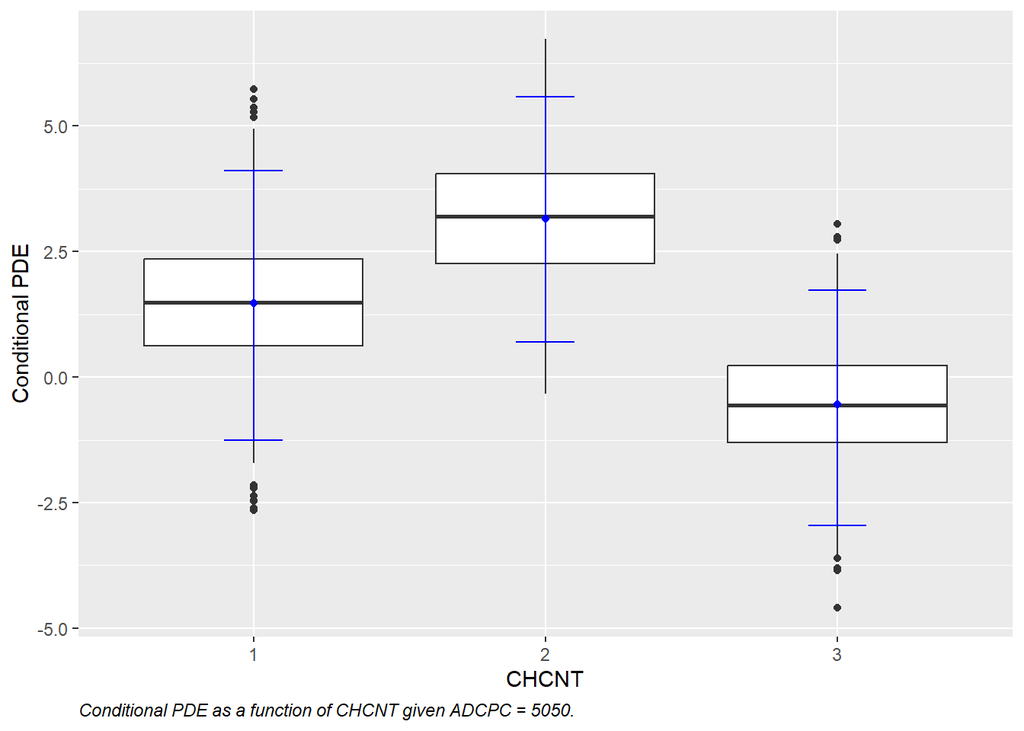

```r
modmed.plot(object = results,
            effect = "PDE",
            moderator = "CHCNT",
            other.mod.cont.values = 5050)
```

**Plot of a conditional causal effect versus a moderator** Each time users choose one focal effect (specified via `effect`, which can be `"TE"`, `"TIE"`, `"PDE"`, `"PIE"`, `"TDE"`, or `"INT"`) to be plotted against a focal moderator (specified via `moderator`), while conditioning on given values of the other moderators (specified via `other.mod.disc.values` for discrete moderators and/or `other.mod.cont.values` for continuous moderators). The length and order of `other.mod.disc.values` must match those of `moderators.disc` (specified in the `modmed` function) with the focal moderator removed if it is discrete. If one does not want to condition some moderators on specific values, one may specify their values to be `NA`. The same is true for `other.mod.cont.values`.

Applying the above syntax to the NEWWS data, we obtained the above figure, which represents how the pure direct effect varied with the number of children that participants had at baseline, among those who received $5050 welfare in the year before randomization. For each category of the moderator, a boxplot is generated to represent the Q estimates of the conditional PDE obtained from the Monte Carlo or bootstrapping algorithm. Each blue dot in the middle represents the final effect estimate, while each blue interval denotes the confidence interval at the confidence level specified in the `modmed` function.

Among those who received $5050 welfare in the year before randomization, the pure direct effect of LFA on maternal depression is estimated to be positive among those with one or two children at baseline, while significant only among those with two children. In contrast, among those with three or more children, LFA would have reduced maternal depression if not changing one’s employment experience, but not by a statistically significant amount. This matches and supplements the numerical summary obtained from the `summary_modmed` function.

**Conditional distribution of a continuous moderator** If the focal moderator is continuous, one can choose to add its sample distribution given values of the other moderators via `is.dist.moderator = TRUE`. It will not be plotted if the subsample within the given levels of the other moderators has fewer than 30 observations. Five percentile lines are added to the distribution of the moderator, which facilitates the evaluation of conditional effects at given percentiles of each continuous moderator. The percentiles can be specified via `probs`. The default is `c(0.1, 0.25, 0.5, 0.75, 0.9)`.

By running the following syntax, we further assessed how the pure direct effect varied with welfare amount in the year before randomization and how the welfare amount is distributed, among those who had two children at baseline.

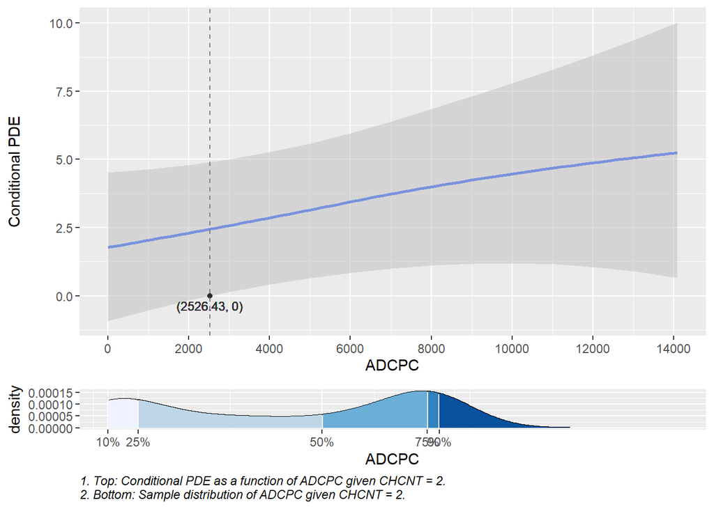

```r
modmed.plot(object = results,
            effect = "PDE",
            moderator = "ADCPC",
            other.mod.disc.values = 2,
            is.dist.moderator = TRUE,
            probs = c(0.1, 0.25, 0.5, 0.75, 0.9),
            ncore = 6)
```

As shown in the above figure, the estimates of the conditional PDE are represented by the blue curve. To obtain such a curve, the function estimates the conditional PDE at each of 15 evenly spaced values of the moderator and fits a loess line to the 15 estimates. Similarly, we obtained the grey band, which represents the confidence band. The dashed vertical lines divide the significant and insignificant regions. The limit of the x-axis is determined by the range of the focal moderator in the whole sample.

From the figure, among those who had two children at baseline, the pure direct effect of LFA on maternal depression increased as one received more welfare amount in the year prior to randomization. The effect is significant when the welfare amount is larger than $2526. The sample distribution of the welfare amount indicates that about 70% of the participants with two children are in the significant region.

By changing “PDE” to the other effects, one at a time, we can obtain a figure for each effect. These figures provide researchers with a general picture of how each effect changes with a moderator given values of the other moderators, as well as the moderator values at which the sign or significance of the effect is flipped. If particularly interested in a visualized difference in an effect between two values of the focal moderator, one may use the `modmed` function to estimate the difference and test its significance. If the figure shows that an effect is linearly associated with a continuous moderator, one may estimate and test the difference in the effect between two arbitrarily chosen moderator values that are one unit apart, which implies the average change in the effect with one unit increase in the moderator.

### 4. Sensitivity analysis

In a causal mediation analysis, it is important to theoretically discuss which unmeasured variables may be confounders, assess how plausible it is, and evaluate how additional adjustment for these potential unmeasured confounders would have changed the sign or significance of the effects. The sensitivity of the analysis results to unmeasured pretreatment confounding can be assessed by passing the output of the `modmed` function via `object` to the `modmed.sens` function.

```r
sens.results = modmed.sens(object = results,
                           sens.effect = c("TIE", "PIE",
                           "TDE", "PDE","INT", "TIE.ref",
                           "PIE.ref", "PDE.ref", "TDE.ref",
                           "INT.ref", "TIE.dif", "PIE.dif",
                           "PDE.dif", "TDE.dif","INT.dif"),
                           range.b.m = NULL,
                           range.b.y = NULL,
                           grid.b.m = 10,
                           grid.b.y = 10,
                           U.scale = "binary",
                           p.u = 0.5,
                           t.rand = TRUE,
                           t.model = NULL,
                           t.scale = "binary",
                           b.t = NULL,
                           iter = 10,
                           nsim = 5,
                           ncore = 6)
```

The effects whose sensitivity will be evaluated can be specified via `sens.effect`. It is a vector, `c("TIE", "PIE", "TDE", "PDE", "INT", "TIE.ref", "PIE.ref", "PDE.ref", "TDE.ref", "INT.ref", "TIE.dif", "PIE.dif", "PDE.dif","TDE.dif", "INT.dif")`, by default (i.e., if `sens.effect` is not specified). `sens.effect` can also be specified as a subvector of the default. It does not matter how the effects are ordered. For example, if a researcher is mainly interested in the sensitivity of moderated indirect effects, `sens.effect` can be specified as `c("PIE.dif", "TIE.dif")`. Following the algorithm for sensitivity analysis, users can specify value ranges for the sensitivity parameters via `range.b.m` and `range.b.y` (e.g., `c(-2, 2)`); the values are automatically generated if NULL is specified. They are divided into a `grid.b.m`-by-`grid.b.y` grid, which is 10-by-10 by default. The finer the grid, the smoother the sensitivity analysis plot as shown later. The sensitivity parameters are the slopes of U in the standardized mediator and outcome models, in which both the independent and dependent variables are standardized. If the dependent variable is binary, its latent index is standardized instead (Grace et al., 2018). The variance of the latent index is the sum of the predictor variance and the assumed error variance (McKelvey & Zavoina, 1975).

As clarified in the sensitivity analysis section, the conditional distribution of U also relies on the marginal distribution of U, which is assumed to be binary (`U.scale = "binary"`) with Pr(U = 1) = 0.5 (`p.u = 0.5`) by default. One can change `U.scale` to be `"continuous"` for a continuous U, which is assumed to follow a standard normal distribution (`sigma.u = 1`) by default. `p.u` and `sigma.u` can be adjusted.

By default, the treatment is randomized (`t.rand = TRUE`). In other words, there is no confounder of the treatment– mediator or treatment–outcome relationship. Hence, by default, `t.model = NULL`. If treatment is not randomized (`t.rand = FALSE`), one needs to specify `t.model` in the same way as specifying `m.model` and `y.model`, because a treatment model is required for the derivation of the conditional distribution of the unmeasured pretreatment confounder U. The names of the elements in `t.model` must include `intercept` and the covariates in `covariates.disc` and `covariates.cont` that predict the treatment (i.e., a covariate that only confounds the mediator-outcome relationship does not need to be included). Each element of the list is equal to a vector of moderators in the function of the main treatment model coefficient. The moderators of the intercept must contain all the moderators in the treatment model because their slopes represent the main effects of the moderators. If a main model coefficient is not moderated, the corresponding vector of moderators needs to be specified as `NULL`. A moderator in the mediator and outcome models does not necessarily moderate any coefficient in the treatment model. If it is only a predictor rather than a moderator in the treatment model, users will only include it in the vector corresponding to the intercept when specifying `t.model`. For example, suppose the treatment is not randomized, we may specify that `t.model` in the `modmed.sens` function as `t.model = list(intercept = c("ADCPC", "CHCNT"), emp_prior = "ADCPC", nevmar = "CHCNT", hispanic = NULL, nohsdip = NULL, workpref = NULL, attitude = NULL, depress_prior = NULL)`.

Besides, a value for sensitivity parameter $\beta^t_u$ needs to be specified via `b.t`. One may use the standardized coefficient estimates of the observed covariates in the treatment model as referent values for the specification of `b.t`. The treatment is binary by default. If the treatment is continuous, `t.scale` needs to be specified as `"continuous"`. The sensitivity analysis is conducted given one single value of $\beta^t_u$. If there are multiple values of $\beta^t_u$ to be assessed, one may conduct the sensitivity analysis multiple times to assess the influence of each value of $\beta^t_u$, one at a time.

In addition, users can specify the number of iterations that the stochastic EM algorithm takes for simulating U (i.e., S) and the number of simulations of U (i.e., K) respectively via `iter` and `nsim`, which are 10 and 5 by default. Each run of the `modmed` function only takes seconds, while the `modmed.sens` function involves `nsim` runs of the `modmed` function, each of which involves `iter` iterations, for each cell of the grid. To speed up calculation, the package allows parallel computing by setting the number of CPU cores via `ncore`. Its default value is 2. A user may use more cores to speed up the program. `detectCores()` can be used to detect the number of all cores available on a computer. It is not recommended to use up all the cores. At least one core should be saved for users to run other programs on the computer while running the R program. A progress bar is displayed as the program runs. An application of the above syntax to the NEWWS data took about 1 hour. It takes less time if `sens.effect` is specified as a subvector of all the effects. For example, it takes 15 minutes if `sens.effect = "TIE.ref"`. We reduced the size of the grid to 5-by-5 and obtained similar results for all the effects in 15 minutes, while the visualized results are less smooth. We would suggest users use a coarse grid (e.g., 5-by- 5) to get a preliminary sense of sensitivity and then use a fine grid (e.g., 10-by-10) for the final report of the sensitivity analysis results. In the cases when Step 2.5 does not involve a spline regression, it takes less than 10 minutes for a 10-by- 10 grid with only one core.

The output includes a `grid.b.m`-by-`grid.b.y` table separately for the point estimates, CI lower bounds, and CI upper bounds of each effect after adjusting for U at the strengths reflected by the column and row names. Each column (row) name corresponds to one of the `grid.b.y` (`grid.b.m`) sensitivity parameter values that evenly divide `range.b.y` (`range.b.m`). The table can be extracted via `sens.results$results.new`. The output also includes slopes of each observed pretreatment confounder in the standardized mediator and outcome models, which can be used as referent values to calibrate the strength of unmeasured pretreatment confounding. The slopes can be extracted via `sens.results$X.coef.plot`.

In the NEWWS example, as illustrated in the identification section, one’s salary expectation at baseline is a potential unmeasured confounder of the relationship between employment and depression within levels of baseline welfare amount and number of children. To assess how an additional adjustment for such an unmeasured confounder would affect the initial results, one may specify the sensitivity parameter values based on prior knowledge about its association with employment and depression or a comparable observed pretreatment covariate. For example, it may be reasoned that the unique confounding role of baseline salary expectation is similar to that of baseline employment. Hence, one may use the standardized coefficient estimates of baseline employment in the mediator and outcome models as referent values when specifying the sensitivity parameters, by setting `range.b.m` and `range.b.m` to the values and setting `grid.b.m` and `grid.b.m` to 1:

```r
modmed.sens(object = results,
            range.b.m = 0.31,
            range.b.y = 0.04,
            grid.b.m = 1,
            grid.b.y = 1)
```

```
## $b.t
## NULL
##
## $X.coef.plot
##               X.coef.plot.m X.coef.plot.y
## emp_prior1       0.31030821    0.04068706
## nevmar1         -0.01940212    0.07875448
## hispanic1        0.03084250    0.08031976
## nohsdip1        -0.10357677    0.02928150
## workpref         0.11993452   -0.02364645
## attitude         0.04843231   -0.04803222
## depress_prior    0.02339182    0.19624892
##
## $range.b.m
## [1] 0.31
##
## $range.b.y
## [1] 0.04
##
## $b.y.all
## [1] 0.04
##
## $b.m.all
## [1] 0.31
##
## $results.new
## $results.new$TIE
##            0.04
## 0.31 -0.7811162
##
## $results.new$CIL.TIE
##           0.04
## 0.31 -1.497193
##
## $results.new$CIU.TIE
##            0.04
## 0.31 -0.1299633
##
## $results.new$PIE
##             0.04
```

[output cut: 150 more lines]

```
## $results.new$CIU.TDE.dif
##           0.04
## 0.31 0.1239682
##
## $results.new$INT.dif
##           0.04
## 0.31 0.5230734
##
## $results.new$CIL.INT.dif
##           0.04
## 0.31 -1.277013
##
## $results.new$CIU.INT.dif
##          0.04
## 0.31 2.370291
```

### 5. Visualization of sensitivity analysis results

The output of the `modmed` function and the output of the `modmed.sens` function can be passed respectively via `object` and `sens.results` to the `sens.plot` function for visualizing the sensitivity analysis results for each effect specified via `effect`, which must be included in `sens.effect` of the `modmed.sens` function.

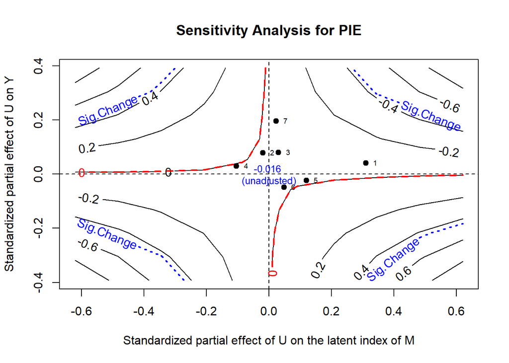

```r
sens.plot(object = results,
          sens.results = sens.results,
          effect = "PIE")
```

Applying the above syntax to the NEWWS data, we obtained the above figure. The X and Y axes are respectively the slopes of U in the standardized mediator and outcome models. The blue number on the origin indicates the original estimate of the pure indirect effect, without adjustment for U. Each black contour represents the combinations of sensitivity parameters that result in the adjusted pure indirect effect estimate as indicated by the number at the end of the contour. The sensitivity parameters on the red dashed contours reduce the PIE estimate to zero. Each blue dotted contour indicates the boundary at which the significance of the PIE is changed at the confidence level specified in the `modmed` function. The adjusted PIE is insignificant in the region that contains the zero lines. The results are more sensitive if the magnitudes of the sensitivity parameters that change the sign or significance of PIE are smaller. The strengths of the sensitivity parameters can be calibrated by the black dots. Each dot is plotted based on the slopes of each observed pretreatment confounder in the standardized mediator and outcome models and thus represents an unmeasured confounder comparable to the observed confounder. A message of which observed confounder each dot is comparable to is displayed after each run of the function.

The above sensitivity analysis plot shows that an additional adjustment of a binary unmeasured pretreatment confounder U with Pr(U = 1) = 0.5 would reverse the sign of PIE as long as the confounding role of U is as strong as one’s baseline educational attainment (`nohsdip`) or work preference (`workpref`). Nevertheless, for the significance of PIE to be altered, U must be much stronger than the strongest observed pretreatment confounder. Because we have controlled for the most important pretreatment confounders in theory, it is almost impossible for the remaining confounders to reverse the significance of PIE even collectively. Hence, the sign of PIE may be sensitive but its significance is more robust. By changing “PIE” to the other effects, one at a time, we can obtain a sensitivity analysis plot for each effect. The plots show that the other effects are mostly robust to unmeasured pretreatment confounding.

In addition, we assessed sensitivity to a continuous U that follows a standard normal distribution and obtained very similar results. It is more computationally intensive because the derivation of the conditional distribution of a continuous U relies on adaptive numerical integration. Hence, if U is expected to follow a standard normal distribution, one may assess its influence by specifying U to be binary with Pr(U = 1) = 0.5 to reduce computing time.

It is worth noting that, if the treatment is not randomized and if $\beta_u^t$ u is specified to be nonzero, the contours would cross the X and Y axes, because even though U is not associated with M (Y), it can still cause bias as long as U is associated with Y (M), given that U is associated with T. In addition, as shown in Fig. 3, the sensitivity analysis plot is symmetric with respect to the origin, indicating that the bias caused by unmeasured confounder $U_1$ and that caused by $U_2$ would be the same when $\beta_{u1}^m = -\beta_{u2}^m$ and $\beta_{u1}^y = -\beta_{u2}^y$. Similarly, when the treatment is not randomized, the bias would be the same only if $\beta_{u1}^t = -\beta_{u2}^t$ in addition to $\beta_{u1}^m = -\beta_{u2}^m$ and $\beta_{u1}^y = -\beta_{u2}^y$. Therefore, at a given nonzero value of $\beta_u^t$, the sensitivity analysis plot is asymmetric about the origin.